# HW 8 script

### Part C

#### Repeat with one bw larger, and one smaller

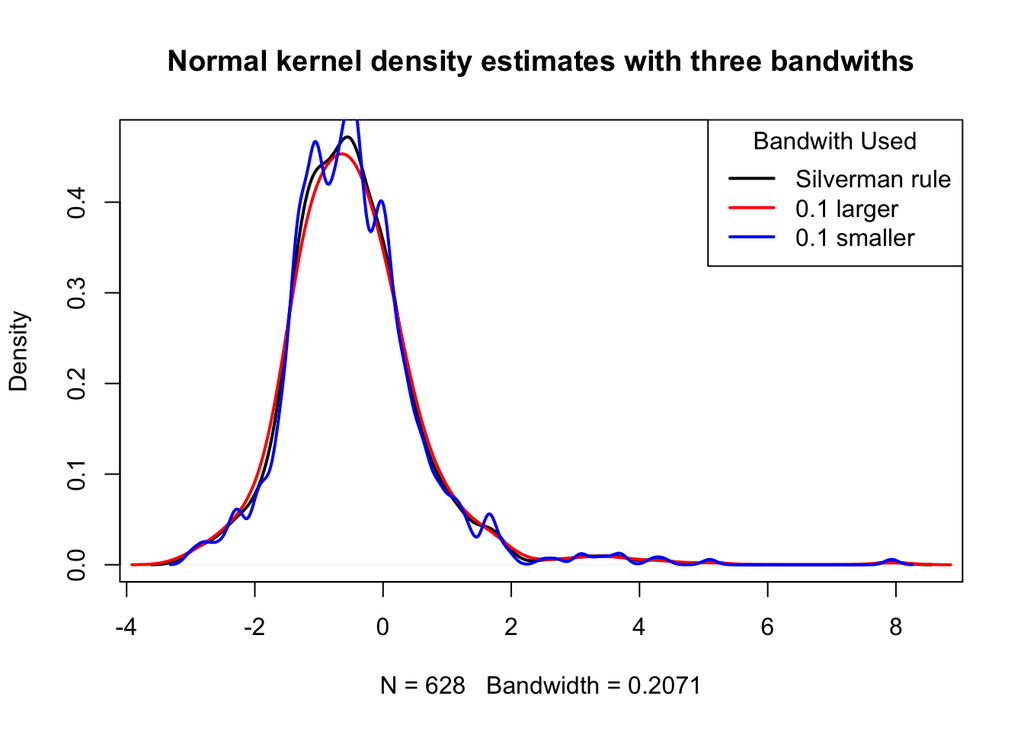

```r
plot(density(infrared$logF12,bw=bw.s, kernel = "gaussian"), col = 1, lwd = 2,
     "Normal kernel density estimates with three bandwiths")
lines(density(infrared$logF12,bw= (bw.s + .1), kernel = "gaussian"), col = 2,lwd = 2)
lines(density(infrared$logF12,bw= (bw.s - .1), kernel = "gaussian"), col = 4,lwd = 2)
legend(x = "topright", legend = c("Silverman rule","0.1 larger", "0.1 smaller"), col = c(1,2,4),lwd = 2, title = "Bandwith Used")
```

Discussion: The Silverman rule of thumb increased by a constant of .1 provided the smoothest curve, though it is unknown if it missed some detail in the density that the regular Silverman rule of thumb provided (showing almost a local maximum just to the left of the global maximum). The blue line, which was produced with a bandwidth smaller than .1 than the Silverman rule created many irregularities. Nevertheless, if the goal were to identify a global maximum, this very erratic line may have been preferred, since it showed the largest density around the global maximum (whereas the other two may have underestimated that point).

### Part D

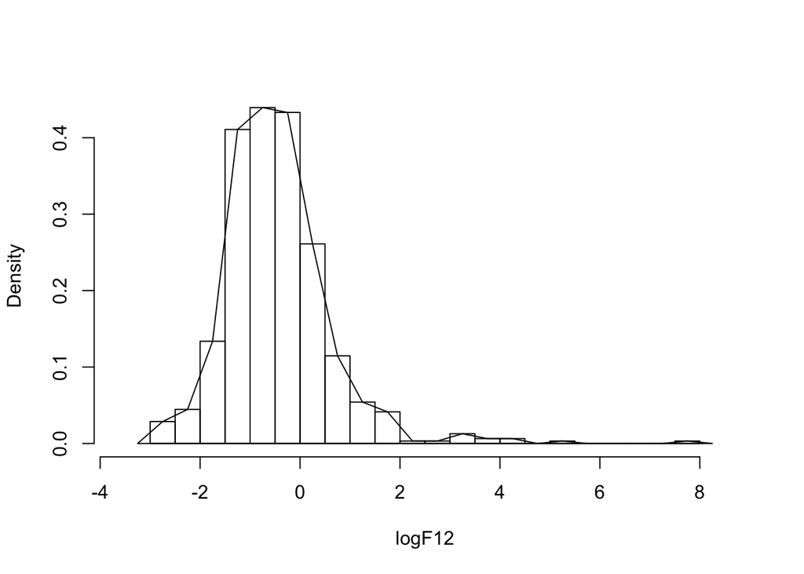

```r
h <- 2.15*sqrt(var(infrared$logF12))*(n^(-1/5))
logF12 <- infrared$logF12
br <- pretty(logF12, diff(range(logF12)) / h)
brplus <- c(min(br)-h, max(br+h))
histg <- hist(logF12, breaks = br, freq = FALSE,
              main = "", xlim = brplus)

vx <- histg$mids
vy <- histg$density
delta <- diff(vx)[1]
k <- length(vx)
vx <- vx + delta
vx <- c(vx[1] - 2 * delta, vx[1] - delta, vx)
vy <- c(0, vy, 0)

# add the polygon to the histogram
polygon(vx, vy)
```